# Spatiotemporal arrays

Edzer Pebesma

1/25/2021

Questions regarding the three papers:

- what is ARD?
- what is the difference between ARD, data cubes, and image collections?
- must ARD, or a data cube, have a regular time discretisation?
- What is a *coverage*, as defined e.g. by OGC in the web coverage service?
- is an image collection always a coverage?
- what does the *stack* method do in the BDC, for temporal aggregation?
- why, in the Maus et al. paper, do the authors propose *time-weighted* dynamic time warping, as opposed to regular dynamic time warping?
- which other questions came up when you read the paper?

### R’s matrix() and image()

```r
m = matrix(1:12, 3, 4)
m
```

```
##      [,1] [,2] [,3] [,4]
## [1,]    1    4    7   10
## [2,]    2    5    8   11
## [3,]    3    6    9   12
```

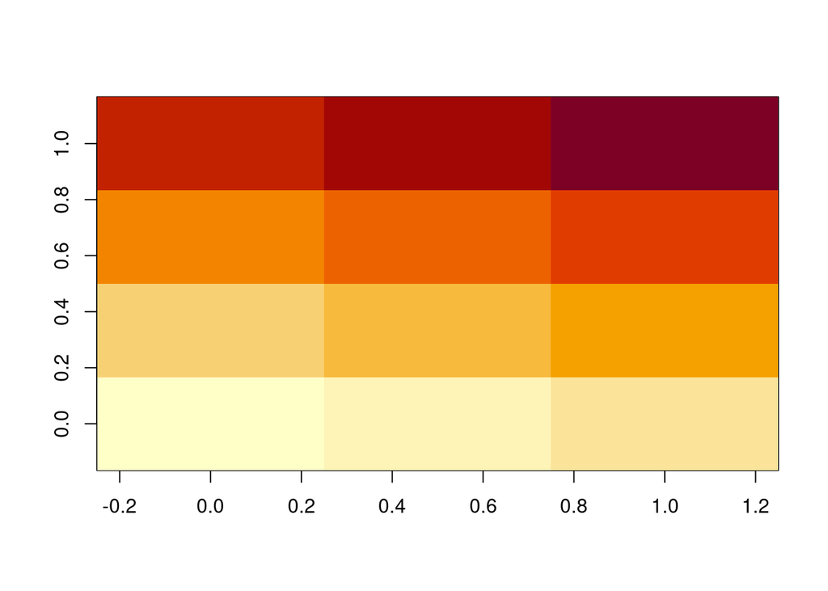

```r
image(m)
```

```r
fortunes::fortune("conventions")
```

```
##
## Mathematical conventions are just that, conventions. They differ by field of
## mathematics. Don't ask us why matrix rows are numbered down but graphs are
## numbered up the y axis, nor why x comes before y but row before column. But the
## matrix layout has always seemed illogical to me.
##    -- Brian D. Ripley (answering a question why the layouts of print(x) and
##       image(x) are different)
##       R-help (August 2004)
```

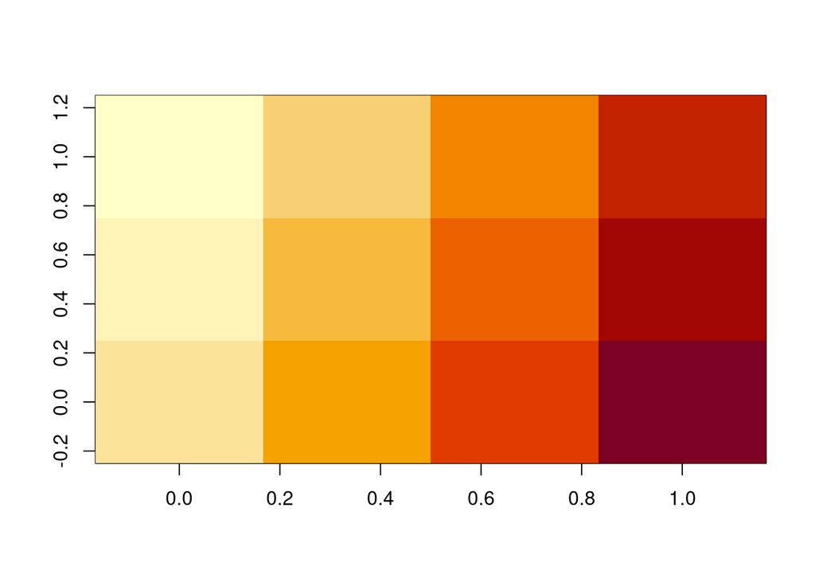

```r
image2 = function(x, ...) {
    x = t(x) # transpose
    x = x[,ncol(x):1] # flip
    image(x, ...)
}
image2(m)
```

```r
n = 25; m = 20
a = array(runif(n * m), c(n, m))
dim(a)
```

```
## [1] 25 20
```

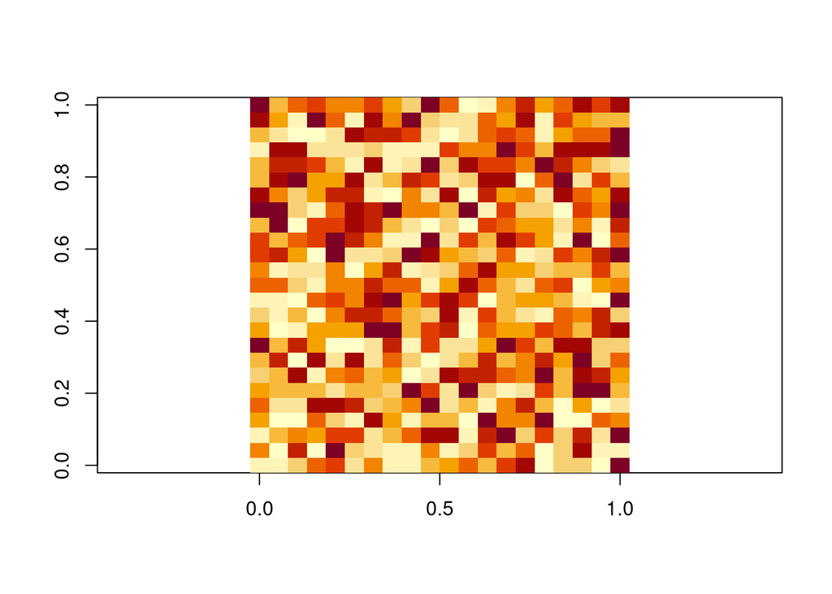

```r
image2(a, asp = 1)
```

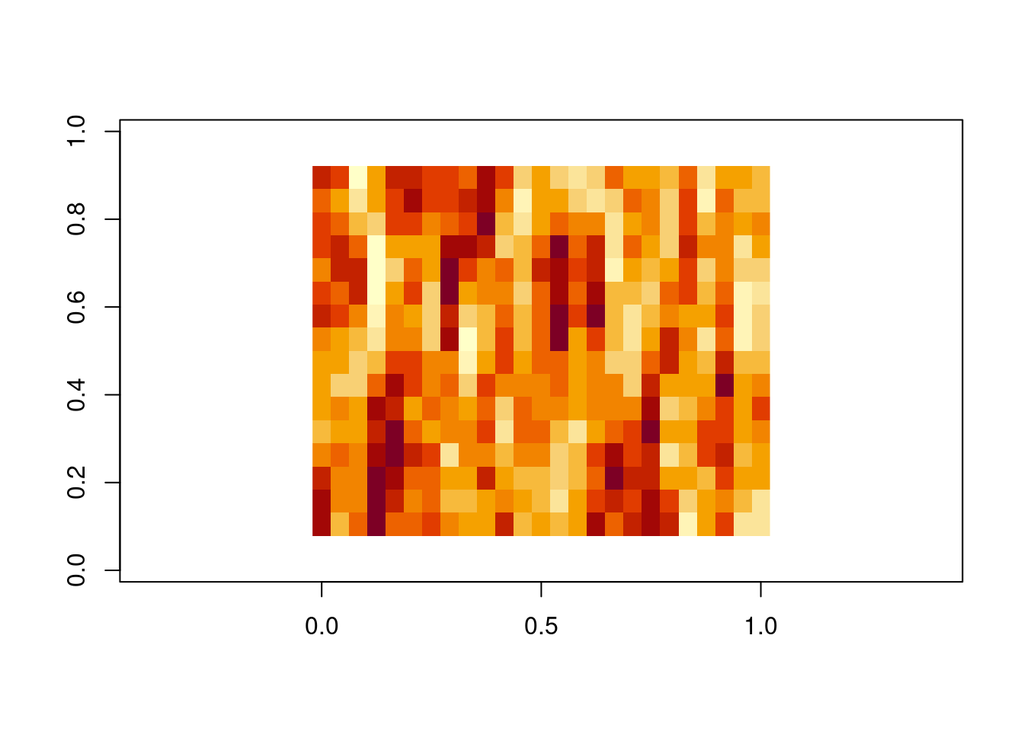

```r
fw = 5 # filter width
a1 = apply(a, 1, filter, filter = rep(1, fw)/fw)
image2(a1, asp = 1)
```

We applied the filter to the rows of the matrix, but see the correlation appear in the columns of the resulting matrix. This is because `apply` puts the dimension over which we iterated (rows) last, so rows have become colums:

```r
dim(a1)
```

```
## [1] 20 25
```

We can further process this two get filtering (moving averaging) on the second dimension, which is again rows of `a1`:

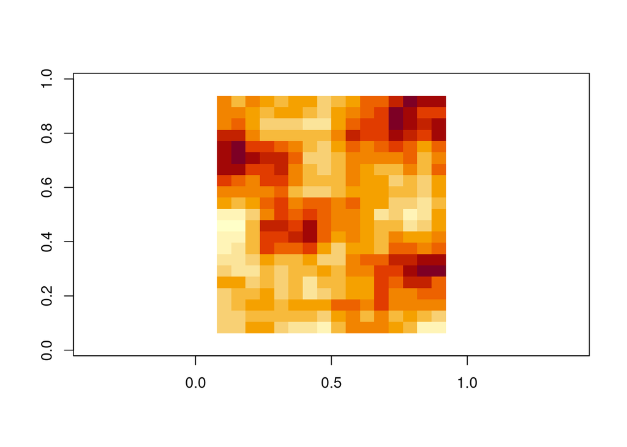

```r
a2 = apply(a1, 1, filter, filter = rep(1, fw)/fw)
image2(a2, asp = 1)
```

```r
dim(a2)
```

```
## [1] 25 20
```

We see that the border two rows and columns are all NA:

```r
a2[1:5,1:5]
```

```
##      [,1] [,2]      [,3]      [,4]      [,5]
## [1,]   NA   NA        NA        NA        NA
## [2,]   NA   NA        NA        NA        NA
## [3,]   NA   NA 0.5030802 0.4636314 0.4958934
## [4,]   NA   NA 0.5009663 0.4988115 0.4923284
## [5,]   NA   NA 0.4989709 0.5229027 0.4837181
```

We can also apply functions that erase the dimension, e.g. mean:

```r
apply(a2, 1, mean, na.rm = TRUE) # row means
```

```
##  [1]       NaN       NaN 0.5150247 0.5155540 0.5112119 0.5330386 0.5293556
##  [8] 0.5220083 0.5066967 0.4888147 0.4756176 0.4883143 0.4692836 0.4828359
## [15] 0.4951025 0.4913600 0.4960115 0.4983032 0.4850099 0.4749165 0.4932965
## [22] 0.4586017 0.4471181       NaN       NaN
```

```r
apply(a2, 2, mean, na.rm = TRUE) # column means
```

```
##  [1]       NaN       NaN 0.4724487 0.4745742 0.4857714 0.5030125 0.4971363
##  [8] 0.4901654 0.4761683 0.4590799 0.4721561 0.5074058 0.5023243 0.5085452
## [15] 0.5167100 0.5190740 0.4987515 0.5233244       NaN       NaN
```

```r
mean(a2, na.rm = TRUE)
```

```
## [1] 0.4941655
```

### package `stars`

```r
library(stars)
```

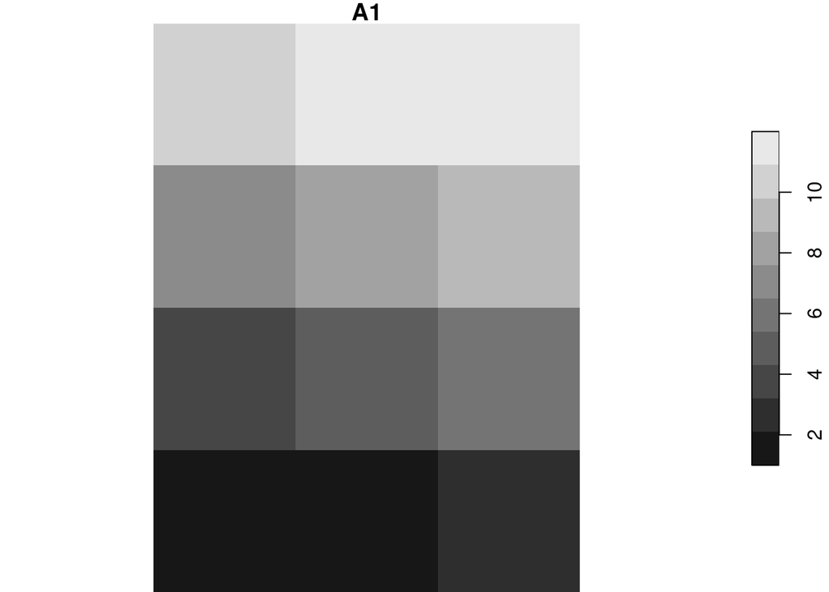

```r
m = matrix(1:12, 3, 4)
m.st = st_as_stars(m)
plot(m.st)
```

```r
str(m.st)
```

```
## List of 1
##  $ A1: int [1:3, 1:4] 1 2 3 4 5 6 7 8 9 10 ...
##  - attr(*, "dimensions")=List of 2
##   ..$ X1:List of 7
##   .. ..$ from  : num 1
##   .. ..$ to    : int 3
##   .. ..$ offset: num 0
##   .. ..$ delta : num 1
##   .. ..$ refsys: chr NA
##   .. ..$ point : logi FALSE
##   .. ..$ values: NULL
##   .. ..- attr(*, "class")= chr "dimension"
##   ..$ X2:List of 7
##   .. ..$ from  : num 1
##   .. ..$ to    : int 4
##   .. ..$ offset: num 0
##   .. ..$ delta : num 1
##   .. ..$ refsys: chr NA
##   .. ..$ point : logi FALSE
##   .. ..$ values: NULL
##   .. ..- attr(*, "class")= chr "dimension"
##   ..- attr(*, "raster")=List of 3
##   .. ..$ affine     : num [1:2] 0 0
##   .. ..$ dimensions : chr [1:2] "X1" "X2"
##   .. ..$ curvilinear: logi FALSE
##   .. ..- attr(*, "class")= chr "stars_raster"
##   ..- attr(*, "class")= chr "dimensions"
##  - attr(*, "class")= chr "stars"
```

```r
class(m.st)
```

```
## [1] "stars"
```

```r
is.list(m.st) # is it a list?
```

```
## [1] TRUE
```

```r
length(m.st) # how many elemenst has this list?
```

```
## [1] 1
```

```r
class(m.st[[1]]) # what's in its first element?
```

```
## [1] "matrix" "array"
```

```r
dim(m.st[[1]])
```

```
## [1] 3 4
```

```r
m.st[[1]]
```

```
##      [,1] [,2] [,3] [,4]
## [1,]    1    4    7   10
## [2,]    2    5    8   11
## [3,]    3    6    9   12
```

### more dimensions

```r
m = array(1:60, c(3,4,5))
m
```

```
## , , 1
##
##      [,1] [,2] [,3] [,4]
## [1,]    1    4    7   10
## [2,]    2    5    8   11
## [3,]    3    6    9   12
##
## , , 2
##
##      [,1] [,2] [,3] [,4]
## [1,]   13   16   19   22
## [2,]   14   17   20   23
## [3,]   15   18   21   24
##
## , , 3
##
##      [,1] [,2] [,3] [,4]
## [1,]   25   28   31   34
## [2,]   26   29   32   35
## [3,]   27   30   33   36
##
## , , 4
##
##      [,1] [,2] [,3] [,4]
## [1,]   37   40   43   46
## [2,]   38   41   44   47
## [3,]   39   42   45   48
##
## , , 5
##
##      [,1] [,2] [,3] [,4]
## [1,]   49   52   55   58
## [2,]   50   53   56   59
## [3,]   51   54   57   60
```

```r
m.st = st_as_stars(m)
m.st
```

```
## stars object with 3 dimensions and 1 attribute
## attribute(s):
##       A1
##  Min.   : 1.00
##  1st Qu.:15.75
##  Median :30.50
##  Mean   :30.50
##  3rd Qu.:45.25
##  Max.   :60.00
## dimension(s):
##    from to offset delta refsys point values x/y
## X1    1  3      0     1     NA FALSE   NULL [x]
## X2    1  4      0     1     NA FALSE   NULL [y]
## X3    1  5      0     1     NA FALSE   NULL
```

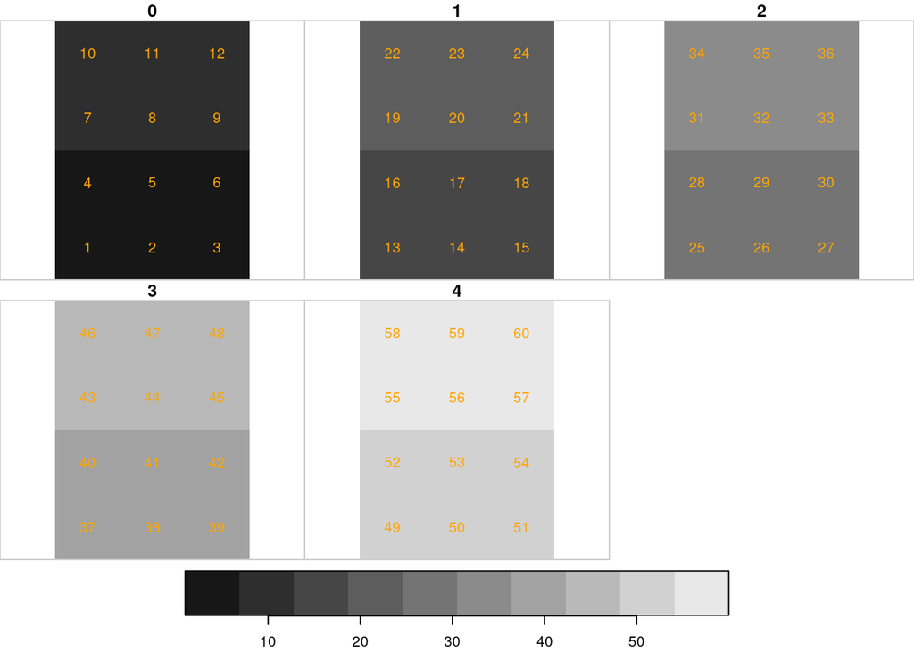

```r
plot(m.st, text_values = TRUE, text_color = 'orange')
```

### higher dimensional data:

```r
dims = c(3,4,5,6,7)
m = array(seq_len(prod(dims)), dims)
m.st = st_as_stars(m)
m.st
```

```
## stars object with 5 dimensions and 1 attribute
## attribute(s):
##       A1
##  Min.   :   1.0
##  1st Qu.: 630.8
##  Median :1260.5
##  Mean   :1260.5
##  3rd Qu.:1890.2
##  Max.   :2520.0
## dimension(s):
##    from to offset delta refsys point values x/y
## X1    1  3      0     1     NA FALSE   NULL [x]
## X2    1  4      0     1     NA FALSE   NULL [y]
## X3    1  5      0     1     NA FALSE   NULL
## X4    1  6      0     1     NA FALSE   NULL
## X5    1  7      0     1     NA FALSE   NULL
```

### real data

```r
tif = system.file("tif/L7_ETMs.tif", package = "stars") # a Landsat-7 image part inside the package
r = read_stars(tif)
r
```

```
## stars object with 3 dimensions and 1 attribute
## attribute(s):
##   L7_ETMs.tif
##  Min.   :  1.00
##  1st Qu.: 54.00
##  Median : 69.00
##  Mean   : 68.91
##  3rd Qu.: 86.00
##  Max.   :255.00
## dimension(s):
##      from  to  offset delta                       refsys point values x/y
## x       1 349  288776  28.5 UTM Zone 25, Southern Hem... FALSE   NULL [x]
## y       1 352 9120761 -28.5 UTM Zone 25, Southern Hem... FALSE   NULL [y]
## band    1   6      NA    NA                           NA    NA   NULL
```

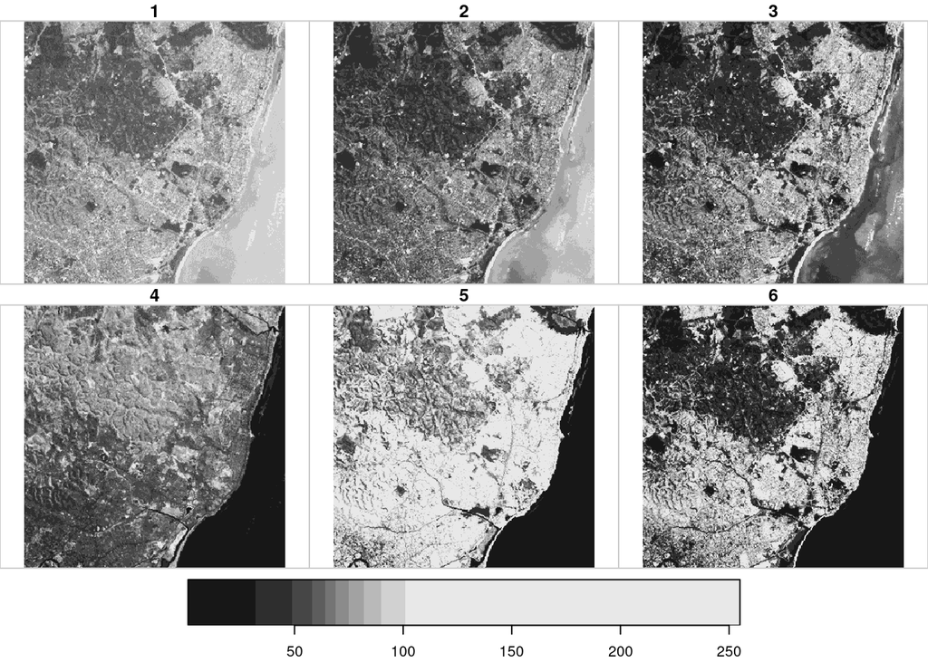

```r
plot(r)
```

Note that: * `offset`, `delta` and `refsys` allow moving from array index to world coordinates, back and forth * the third dimension here refers to spectral bands, this can also be time, or third time + fourth band etc. * `point` registers (*can* register) whether cell values refer to points or areas (support) * `values` may give values (e.g. band names, or continuous values if discretisation of the dimensions is *not* regular) * `[x]` and `[y]` indicate which variables map the horizontal (hopefully: x and y) dimensions * a “discrete axis” can refer to a set of (unordered) geometries, leading to vector data cubes

Example of a time series, with curvilinear coordinates:

```r
library(dplyr)
prec_file = system.file("nc/test_stageiv_xyt.nc", package = "stars")
(prec = read_ncdf(prec_file, curvilinear = c("lon", "lat"), ignore_bounds = TRUE))
```

```
## no 'var' specified, using Total_precipitation_surface_1_Hour_Accumulation
```

```
## other available variables:
##  time_bounds, lon, lat, time
```

```
## No projection information found in nc file.
##  Coordinate variable units found to be degrees,
##  assuming WGS84 Lat/Lon.
```

```
## stars object with 3 dimensions and 1 attribute
## attribute(s):
##  Total_precipitation_surface_1_Hour_Accumulation [kg/m^2]
##  Min.   :  0.000
##  1st Qu.:  0.000
##  Median :  0.750
##  Mean   :  4.143
##  3rd Qu.:  4.630
##  Max.   :163.750
## dimension(s):
##      from  to                  offset   delta  refsys point
## x       1  87                      NA      NA  WGS 84    NA
## y       1 118                      NA      NA  WGS 84    NA
## time    1  23 2018-09-13 19:00:00 UTC 1 hours POSIXct    NA
##                              values x/y
## x    [87x118] -80.6113,...,-74.8822 [x]
## y      [87x118] 32.4413,...,37.6193 [y]
## time                           NULL
## curvilinear grid
```

```r
sf::read_sf(system.file("gpkg/nc.gpkg", package = "sf"), "nc.gpkg") %>%
  st_transform(st_crs(prec)) -> nc # transform from NAD27 to WGS84
nc_outline = st_union(st_geometry(nc))
```

```
## although coordinates are longitude/latitude, st_union assumes that they are planar
```

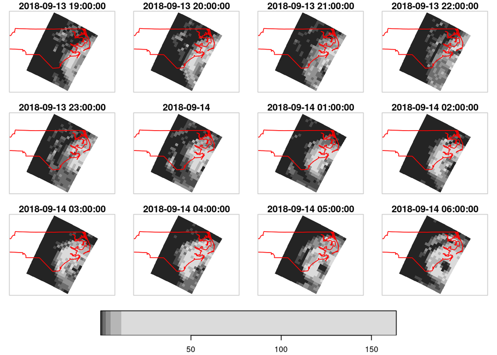

```r
plot_hook = function() plot(nc_outline, border = 'red', add = TRUE)
prec %>%
  slice(index = 1:12, along = "time") %>%
  plot(downsample = c(5, 5, 1), hook = plot_hook)
```